# Module 3: Data visualization II

PUBHLT0411: Statistical Packages for Public Health Data Analysis

Rebecca Deek, PhD

University of Pittsburgh, Biostatistics and Health Data Science

## Housekeeping/setup

```r
# the code below will load the necessary packages for these slides
# packages are normally loaded using library(packageName) after installing them.
# the `pacman` package has a function called `p_load` that checks if a package is
# installed. If it isn't installed, it will install it, otherwise it will load it.

# this line installs the pacman package, if you need it
if(!require(pacman)){
  install.packages(pacman)
  library(pacman)
}

pacman::p_load(countdown)
pacman::p_load(MASS)
pacman::p_load(tidyverse)
pacman::p_load(datasauRus)
pacman::p_load(ggpubr)
pacman::p_load(wesanderson)
pacman::p_load(patchwork)

# data setup
data(birthwt)

birthwt$smoke = factor(birthwt$smoke,
                       levels = 0:1,
                       labels = c("Nonsmoker", "Smoker"))

birthwt$race = factor(x = birthwt$race,
                      levels = 1:3,
                      labels = c("White", "Black", "Other"))

birthwt$low = factor(x = birthwt$low,
                     levels = 0:1,
                     labels = c("No", "Yes"))
```

## `geom_histogram()`

- Continuous variable on the x-axis, divided into equally spaced bins.
- Height of a bar displays the number of observations that fall in each bin.

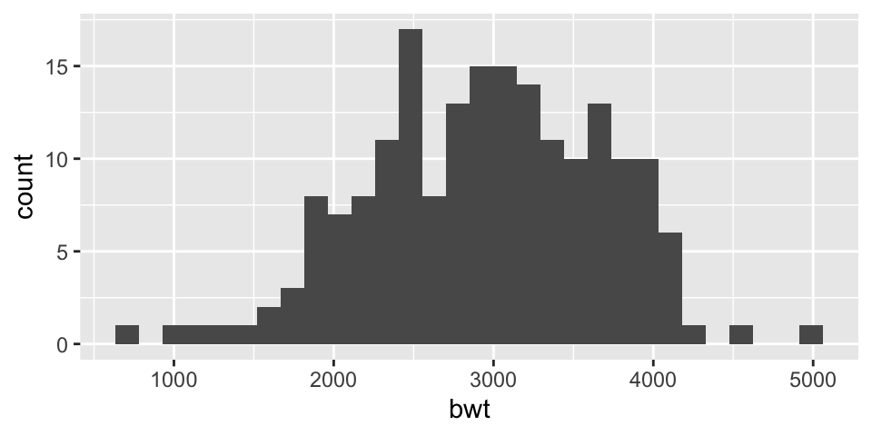

```r
histPlot.bwt = ggplot2::ggplot(birthwt,
                               aes(x = bwt)
                               ) +
  ggplot2::geom_histogram()
histPlot.bwt
```

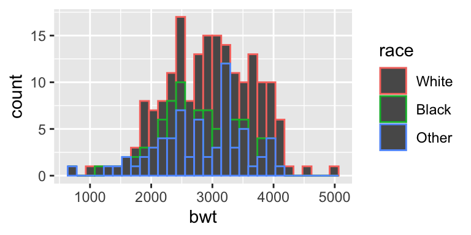

```r
ggplot2::ggplot(birthwt,
                aes(x = bwt,
                    color = race)) +
  ggplot2::geom_histogram()
```

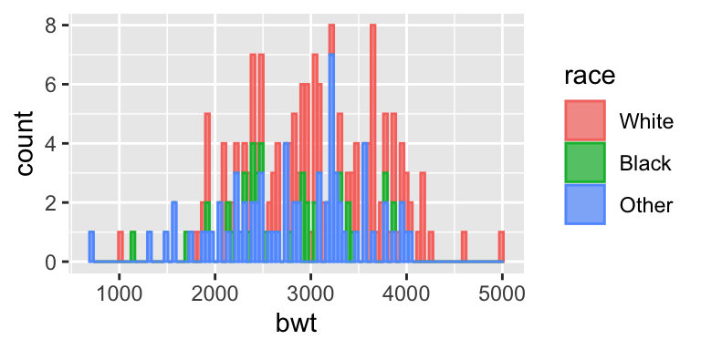

```r
ggplot2::ggplot(birthwt,
                aes(x = bwt,
                    color = race, fill = race)) +
  ggplot2::geom_histogram(alpha = 0.7, bins = 100)
```

## `geom_density()`

- Continuous variable on the x-axis.
- Smoothed version of a histogram.

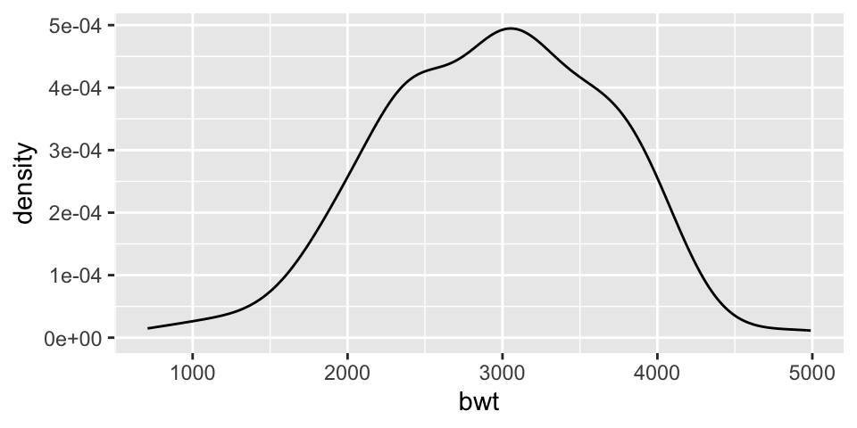

```r
densityPlot.bwt = ggplot2::ggplot(birthwt,
                                  aes(x = bwt)
                                  ) +
  ggplot2::geom_density()
densityPlot.bwt
```

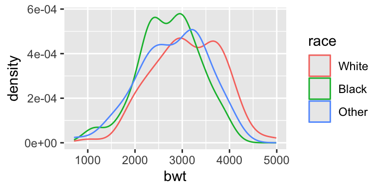

```r
ggplot2::ggplot(birthwt,
                aes(x = bwt,
                    color = race)) +
  ggplot2::geom_density()
```

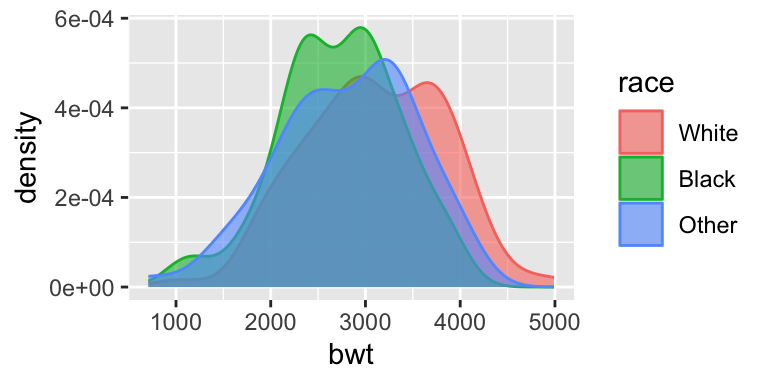

```r
ggplot2::ggplot(birthwt,
                aes(x = bwt,
                    color = race, fill = race)) +
  ggplot2::geom_density(alpha = 0.6)
```

## `geom_boxplot()`

- Continuous variable on the y- or x-axis provides visualization, as well as measures of central tendency and spread.

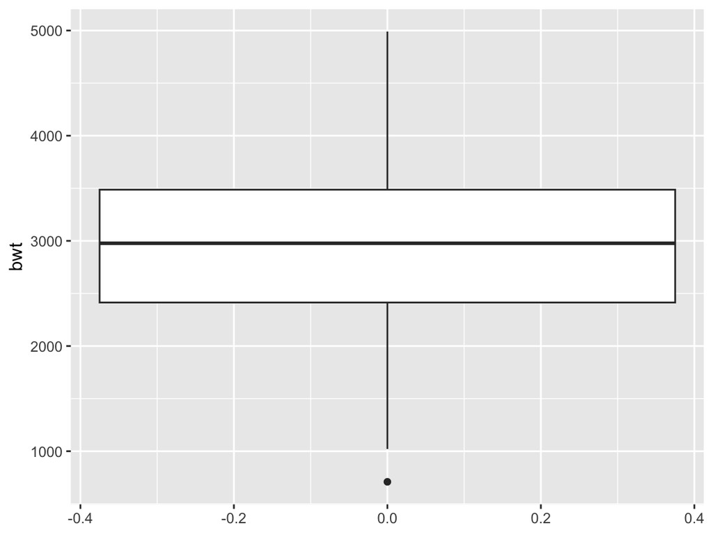

```r
ggplot2::ggplot(birthwt, aes(y=bwt)) +
  ggplot2::geom_boxplot()
```

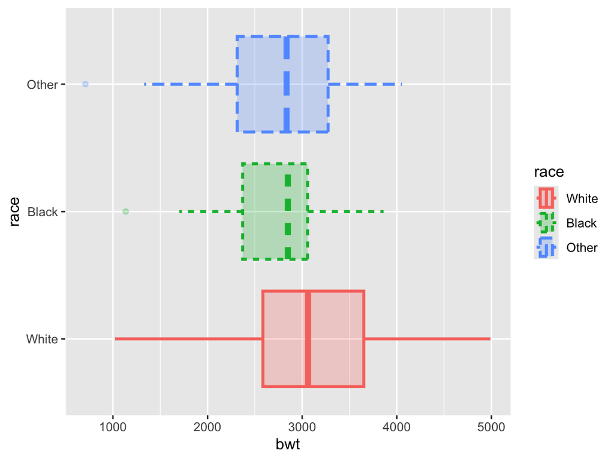

```r
ggplot2::ggplot(birthwt, aes(x = bwt, y = race,
                             color = race,
                             fill = race,
                             linetype = race)) +
  ggplot2::geom_boxplot(alpha = 0.25,
                        linewidth = 1)
```

- Two continuous variables (x- and y-axis), continuous or categorical variables for aesthetics.
- Can plot categorical variables on axes but not as informative.

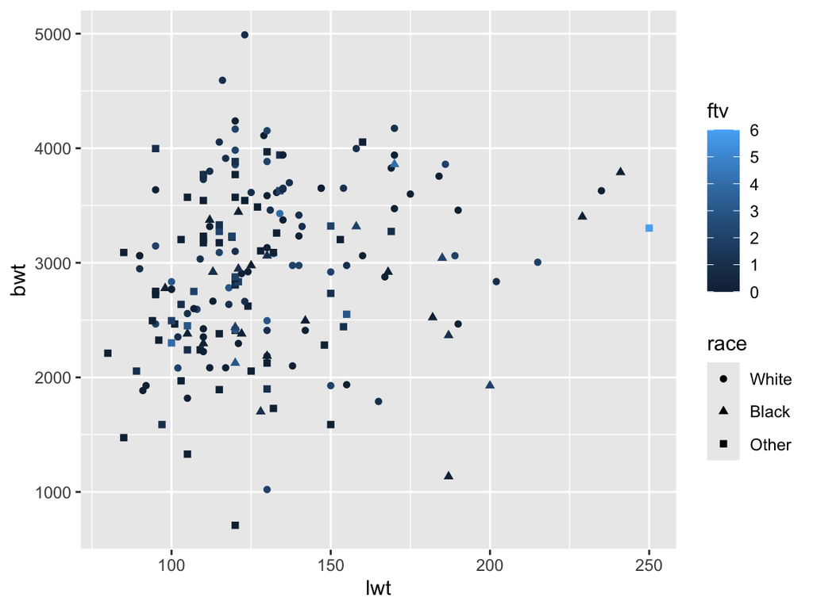

```r
ggplot2::ggplot(birthwt, aes(x = lwt, y = bwt) ) +
  ggplot2::geom_point(aes(color = ftv, shape = race))
```

## `geom_violin()`

- Hybrid between a boxplot and density plot.
  - Displays the distribution and probability density of the data.
  - Mirrored and rotated density plot.
- “Width” of the violin represents frequency of the data points in a given area.
  - Wider sections indicate higher density.

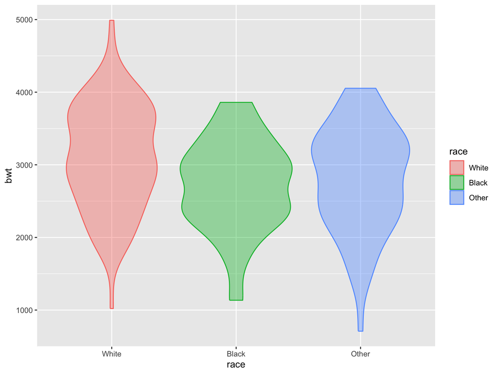

```r
violinPlot.bwt.race = birthwt |>
  ggplot2::ggplot(aes(y = bwt,
                      x = race,
                      color = race)
                  ) +
  ggplot2::geom_violin(
    aes(fill = race),
    alpha = 0.4
    )

violinPlot.bwt.race
```

## Geoms

- `ggplot2` provides more than 40 geoms.
- We will cover a few more but not all possible plots one could make.
- Look into [extension packages](https://exts.ggplot2.tidyverse.org/gallery/) to see what others have created.
  - And maybe for your final project!

## Exercise: ggplot2

Determine why the code doesn’t produce a plot as expected (or at all) and identify a solution.

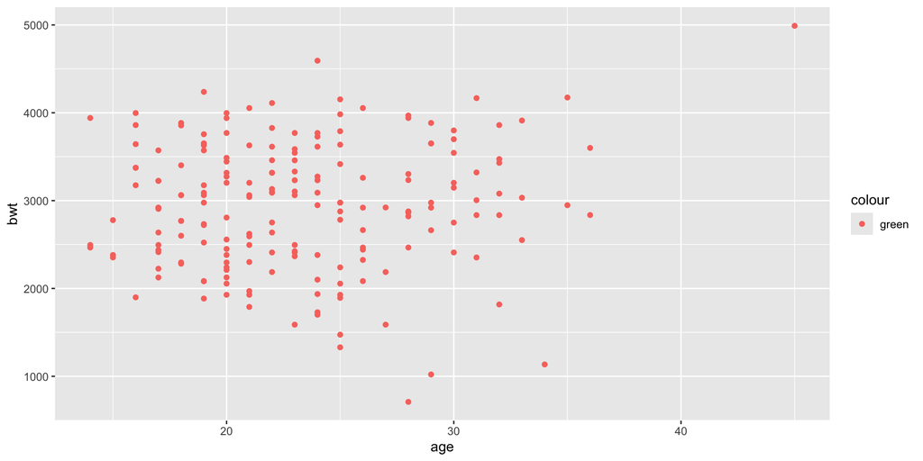

```r
ggplot2::ggplot(birthwt,
                aes(x = age,
                    y = bwt) ) +
  geom_point(aes(color = "green"))
```

```r
ggplot2::ggplot(birthwt,
                aes(x = lwt,
                    y = bwt) ) +
  geom_point(aes(shape = ui))
```

```
Error in `geom_point()`:
! Problem while computing aesthetics.
ℹ Error occurred in the 1st layer.
Caused by error in `scale_f()`:
! A continuous variable cannot be mapped to the shape aesthetic.
ℹ Choose a different aesthetic or use `scale_shape_binned()`.
```

## Layering geoms: Scatterplot example

- Geoms can show similar or complementary information about the data
  - We can combine multiple `geom_*()` functions into a single plot.

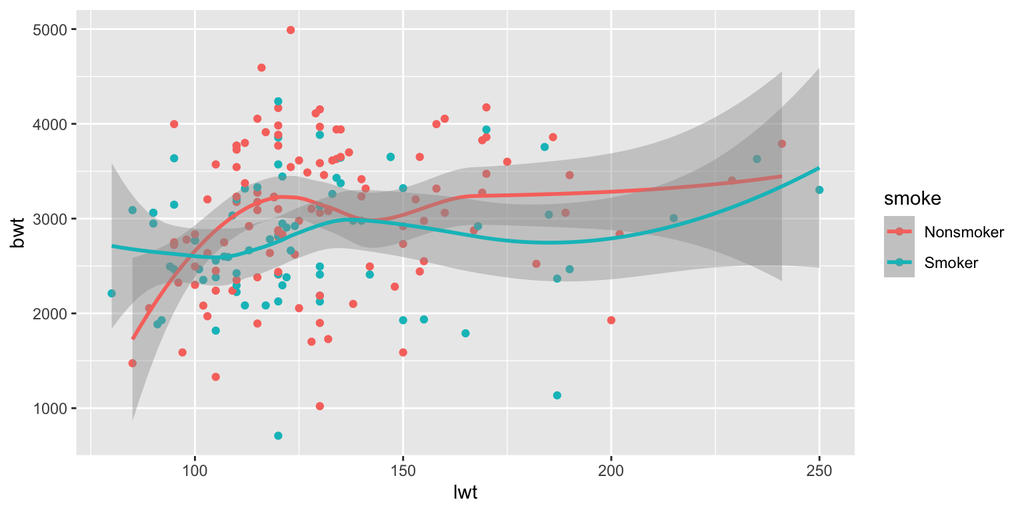

```r
birthwt |>
  ggplot2::ggplot(aes(x = lwt,
                      y = bwt) ) +
  ggplot2::geom_point(aes(color = smoke)) +
  ggplot2::geom_smooth(aes(color = smoke))
```

## Layering geoms: Order matters

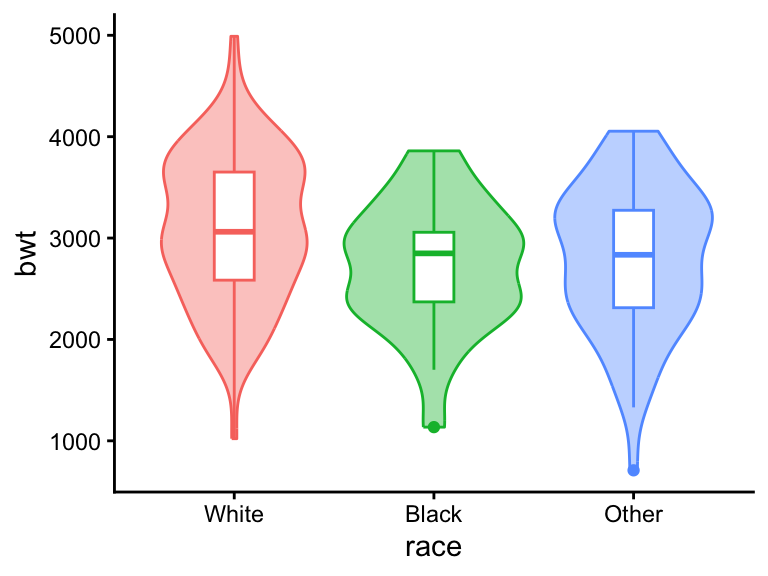

```r
birthwt |>
  ggplot(aes(y = bwt,
             x = race,
             color = race) ) +
  geom_violin(aes(fill = race),
              alpha = 0.4 ) +
  geom_boxplot(width = 0.2) +
  theme_classic() +
  theme(legend.position = "none")
```

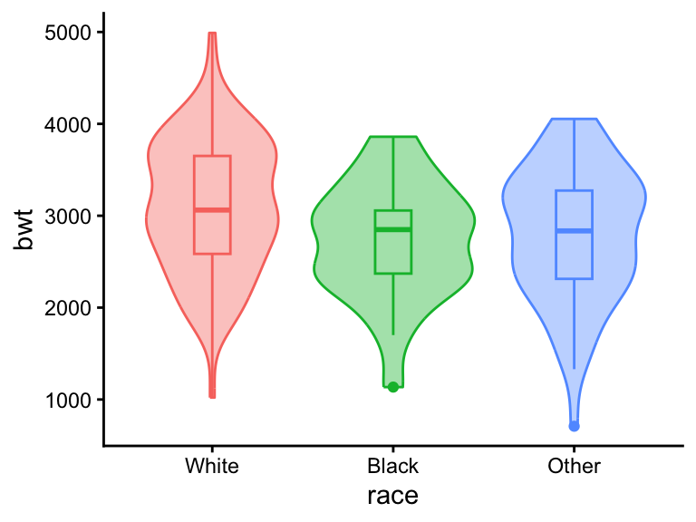

```r
birthwt |>
  ggplot(aes(y = bwt,
             x = race,
             color = race) ) +
  geom_boxplot(width = 0.2) +
  geom_violin(aes(fill = race),
              alpha = 0.4 ) +
  theme_classic() +
  theme(legend.position = "none")
```

## Statistical transformations

Some geoms apply statistical transformations to the supplied data prior to plotting. E.g.,

- `geom_boxplot` calculates a five-number summary.
- `geom_bar` counts the number of observations per group.
- `geom_smooth` fits a regression model and plots its predictions.

Every geom has a default (implicit) stat. Even those that don’t perform transformations (`stat = identity`).

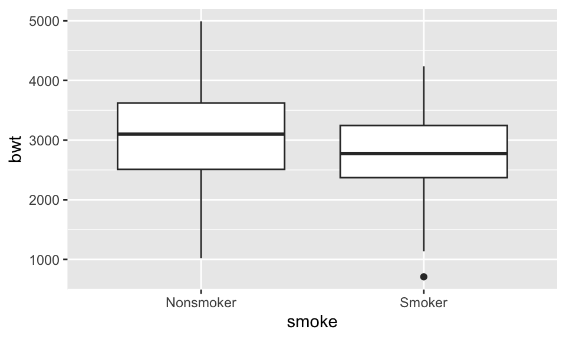

```r
birthwt |>
  ggplot2::ggplot(aes(y = bwt, x = smoke)) +
  ggplot2::geom_boxplot()
```

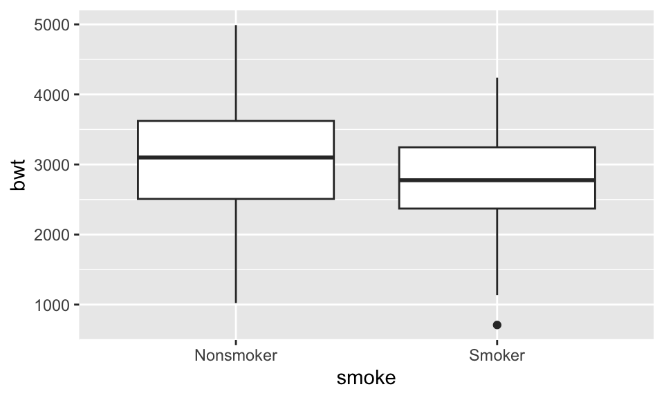

```r
birthwt |>
  ggplot2::ggplot(aes(y = bwt, x = smoke)) +
  ggplot2::geom_boxplot(stat = "boxplot")
```

## Implicit statistical transformations

- `stat = "count"` is the default for `geom_bar`.

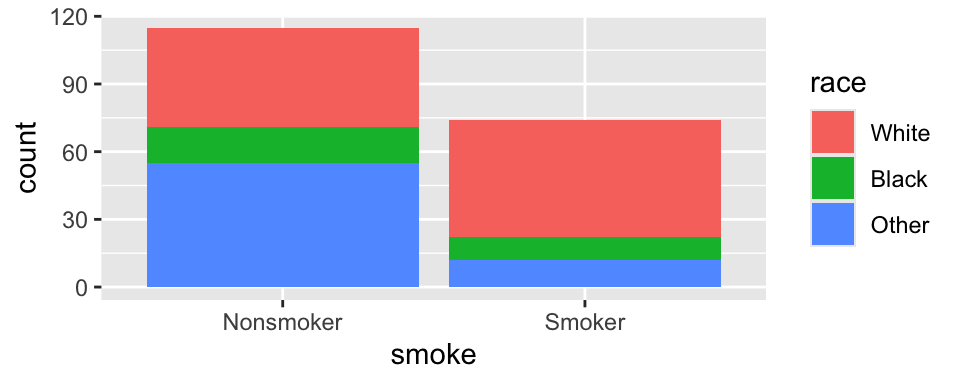

```r
birthwt |>
  ggplot2::ggplot(aes(x = smoke,
                      fill = race) ) +
  ggplot2::geom_bar() # default: stat = "count"
```

```r
bw.smoke.race.count = birthwt |>
  dplyr::group_by(smoke, race) |>
  dplyr::count()
bw.smoke.race.count
```

```
# A tibble: 6 × 3
# Groups:   smoke, race [6]
  smoke     race      n
  <fct>     <fct> <int>
1 Nonsmoker White    44
2 Nonsmoker Black    16
3 Nonsmoker Other    55
4 Smoker    White    52
5 Smoker    Black    10
6 Smoker    Other    12
```

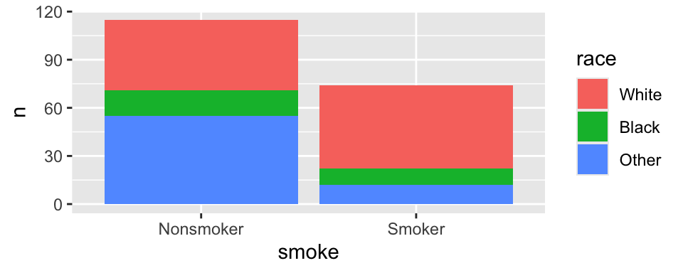

```r
bw.smoke.race.count |>
  ggplot2::ggplot(aes(x = smoke, y = n,
                      fill = race)) +
  ggplot2::geom_bar(stat = "identity")
```

## Aesthetics of stat transformations

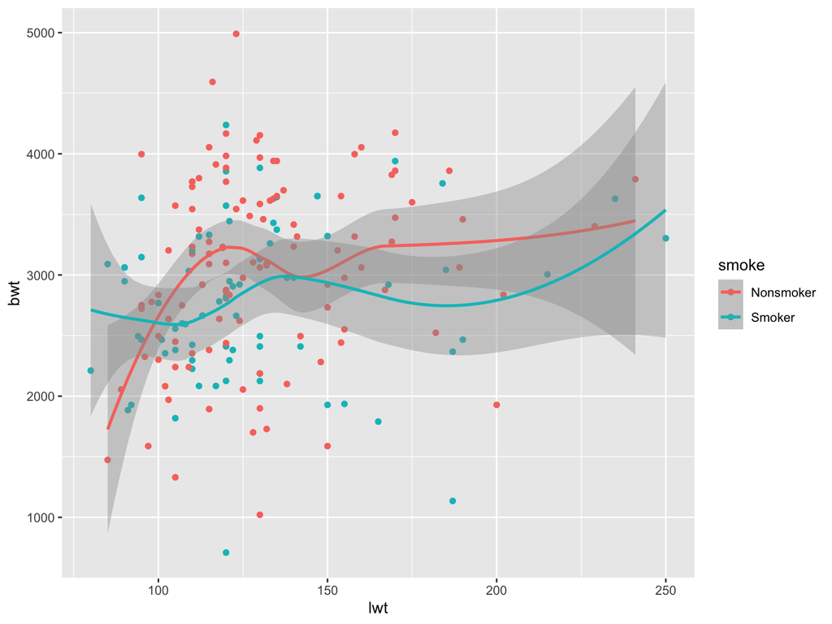

```r
birthwt |>
  ggplot2::ggplot(aes(x = lwt,
                      y = bwt,
                      color = smoke) ) +
  ggplot2::geom_point() +
  ggplot2::geom_smooth()
```

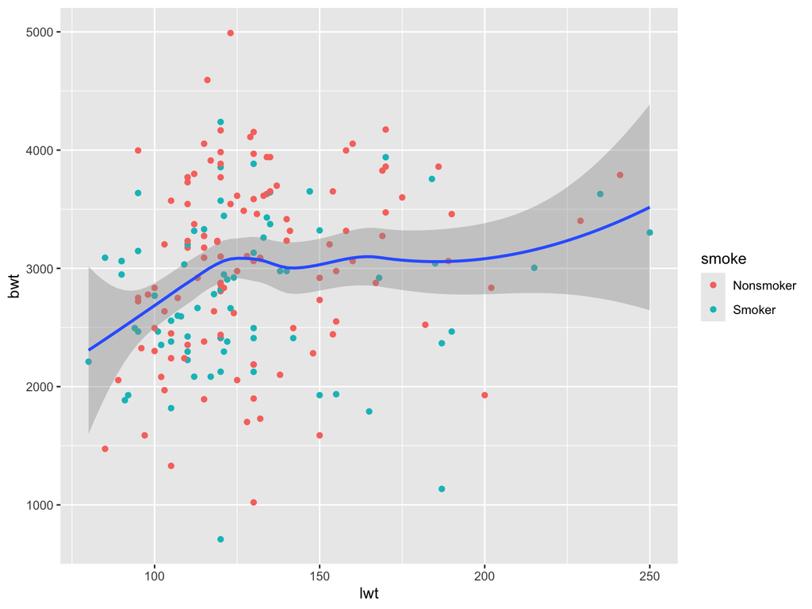

```r
birthwt |>
  ggplot2::ggplot(aes(x = lwt,
                      y = bwt) ) +
  ggplot2::geom_point(aes(color = smoke) ) +
  ggplot2::geom_smooth()
```

## Facets

- Facets generate multiple small plots each showing different subsets of the data.
- Helps compare variables based on a conditioning variable.
  - E.g., the relationship between age and birthweight *given* smoking status and/or race.
- Conditioning variable must be categorical.
  - Discretize continuous variables.

## Types of facets

There are three types of facets:

- `facet_null()`: generates a single plot (the default).
- `facet_wrap()`: “wraps” a 1d set of panels into 2d.
- **`facet_grid()`: produces a 2d grid of panels defined by two variables.**
  - One variable for rows and one for columns.

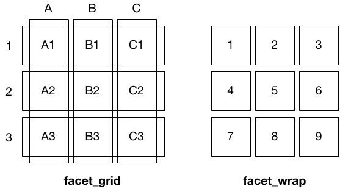

We will primary concern ourselves with `facet_grid()` as it can work for one or two faceting variables.

## `facet_grid()`

- Formula syntax: `facet_grid(rowVar~columnVar)`

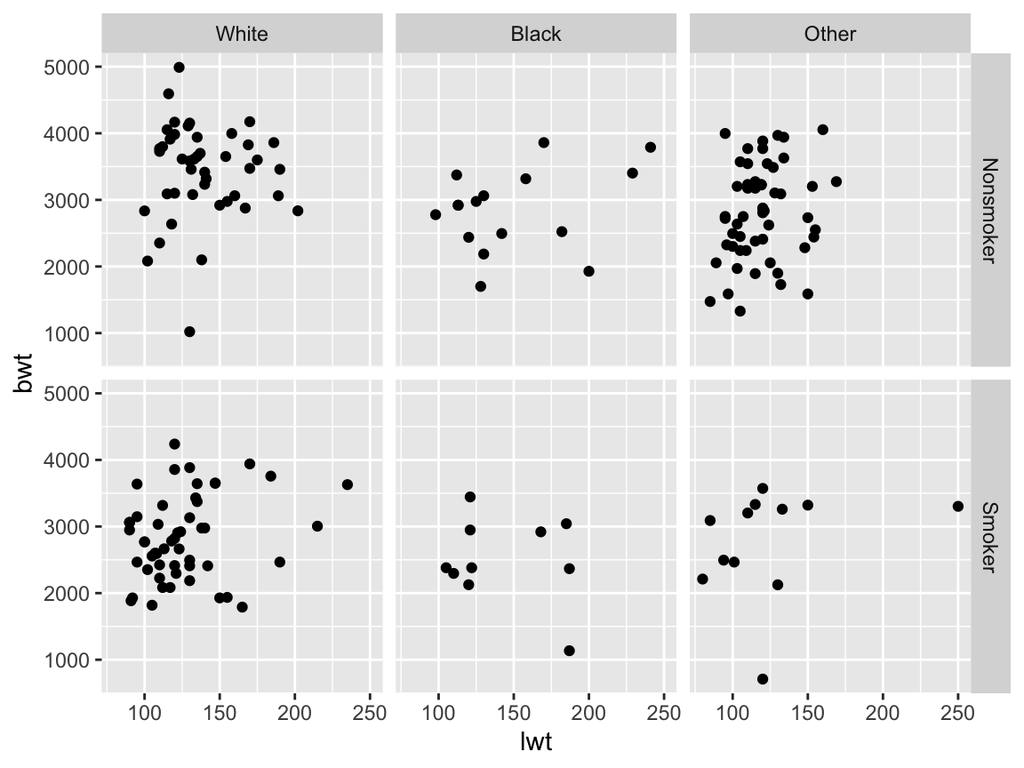

```r
birthwt |>
  ggplot2::ggplot(aes(x = lwt, y = bwt) ) +
  ggplot2::geom_point() +
  ggplot2::facet_grid(smoke~race) # facet: smoke (row) by race (column)
```

## Facets vs. aesthetics

- Compare using only aesthetic combinations (left) to combining facets *with* aesthetics (right).

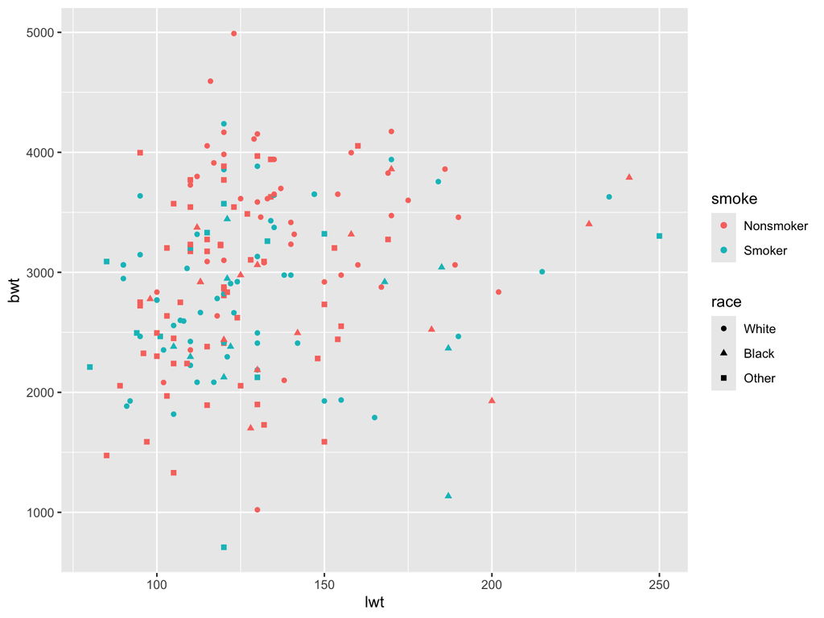

```r
birthwt |>
  ggplot2::ggplot(aes(x = lwt, y = bwt) ) +
  ggplot2::geom_point(aes(color = smoke,
                          shape = race))
```

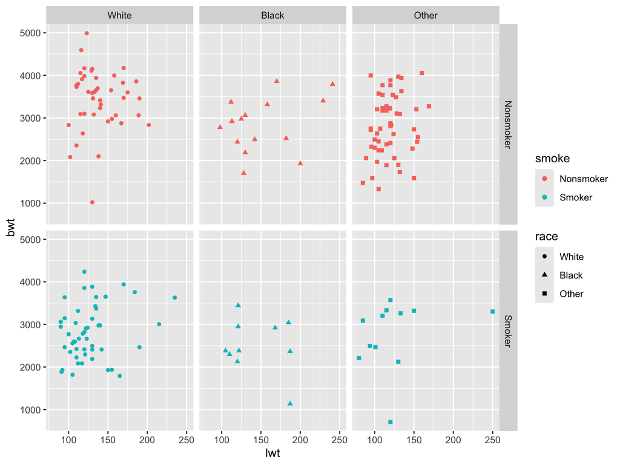

```r
birthwt |>
  ggplot2::ggplot(aes(x = lwt, y = bwt) ) +
  ggplot2::geom_point(aes(color = smoke,
                          shape = race)) +
  ggplot2::facet_grid(smoke~race)
```

## Facets with fixed layout

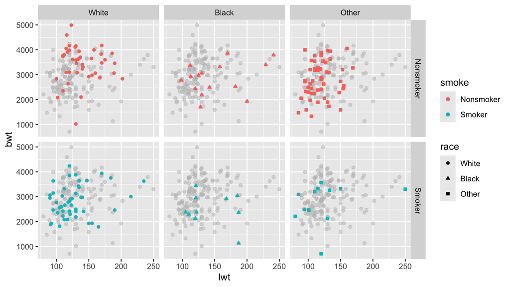

```r
birthwt |>
  ggplot2::ggplot(aes(x = lwt, y = bwt) ) +
  # plot all points in grey and fix them across facets
  ggplot2::geom_point(color = "grey", alpha = 0.5, layout = "fixed") +
  # plot all points and color by smoke no fixed layout -> will be faceted
  ggplot2::geom_point(aes(color = smoke, shape = race)) +
  ggplot2::facet_grid(smoke~race)
```

## Column-only vs. row-only facets

- `. ~ var` column-wise facet.
  - Good for comparison of the y-axis because the vertical scales are aligned.
- `var ~ .` row-wise facet.
  - Good for comparison of the x-axis because the horizontal scales are aligned.

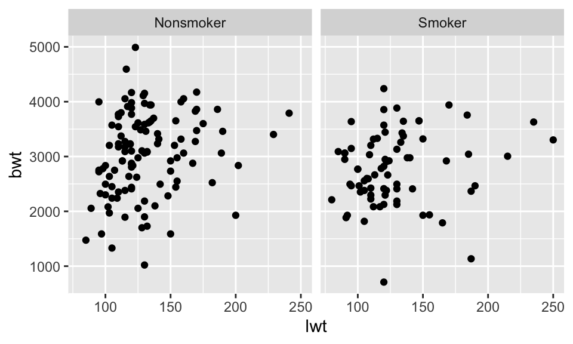

```r
birthwt |>
  ggplot2::ggplot(aes(x = lwt, y = bwt) ) +
  ggplot2::geom_point() +
  ggplot2::facet_grid(.~smoke)
```

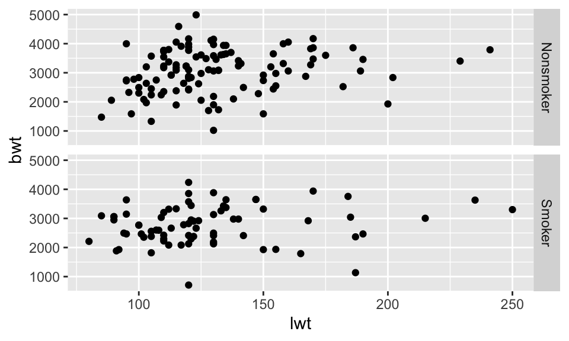

```r
birthwt |>
  ggplot2::ggplot(aes(x = lwt, y = bwt) ) +
  ggplot2::geom_point() +
  ggplot2::facet_grid(smoke~.)
```

## Facet axes

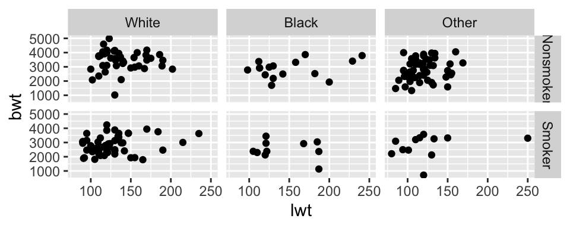

```r
birthwt |>
  ggplot(aes(x = lwt, y = bwt) ) +
  geom_point() +
  facet_grid(smoke~race, axes = "margins" ) # default
```

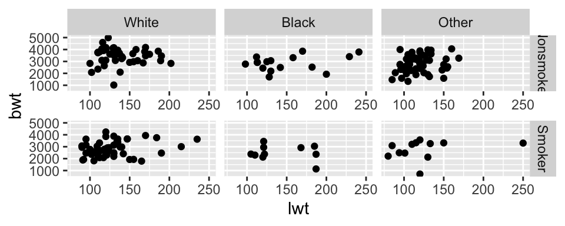

```r
birthwt |>
  ggplot(aes(x = lwt, y = bwt) ) +
  geom_point() +
  facet_grid(smoke~race, axes = "all_x")
```

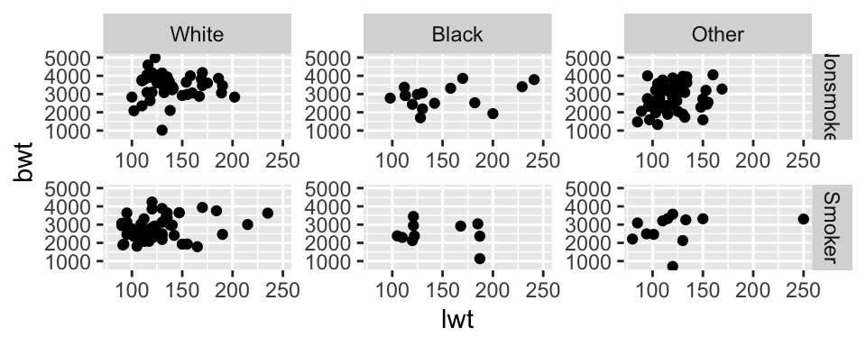

```r
birthwt |>
  ggplot(aes(x = lwt, y = bwt) ) +
  geom_point() +
  facet_grid(smoke~race, axes = "all")
```

[figure not shown]

```r
birthwt |>
  ggplot(aes(x = lwt, y = bwt) ) +
  geom_point() +
  facet_grid(smoke~race, axes = "all_y")
```